# Orphans and Archetypes: KBo 44.52 and EBo 133 (Mainz 2026)

Orphans and Archetypes

Linking unidentified ritual fragments to Hittite textual traditions through quantitative scribal tradition mapping

Shai Gordin

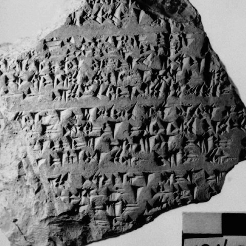

KBo 44.52

*Konk.*: CTH 470

→ AZU-priest rituals

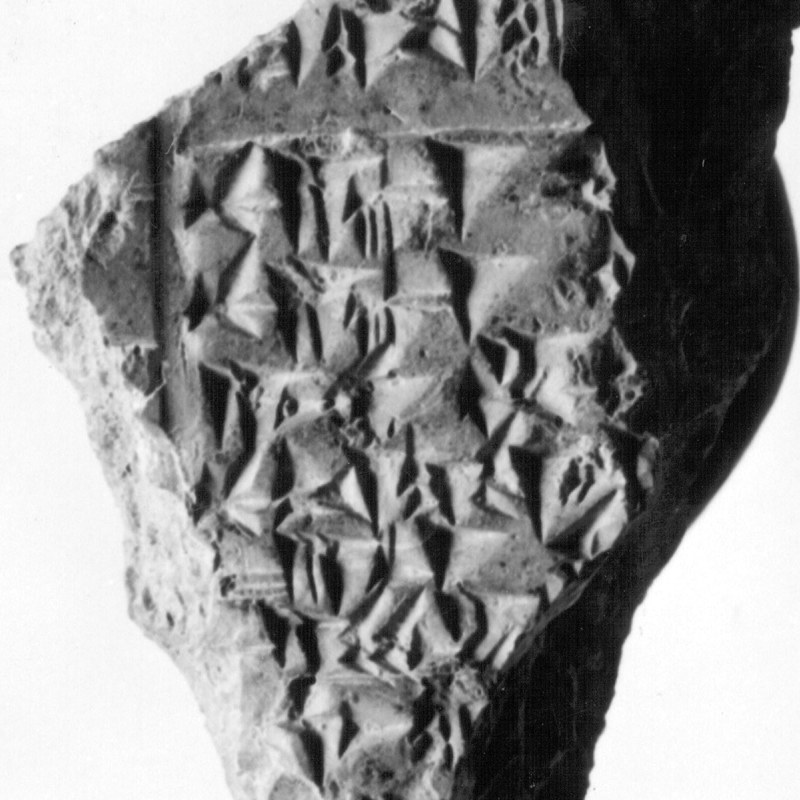

KBo 57.54

*Konk.*: CTH 470

→ placed with restoration

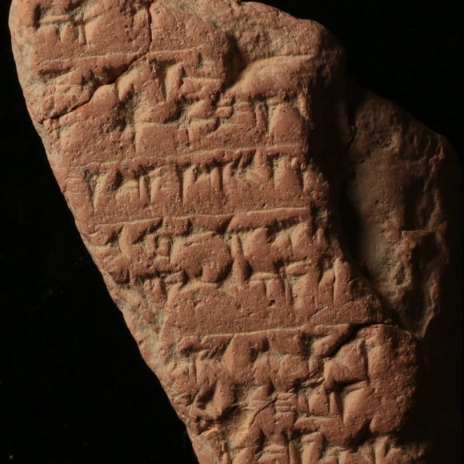

EBo 133

TLHdig: CTH 670

→ suggested join?

[figure not shown]

AI: Potential for Reconstruction and Analysis of Cuneiform Texts Mainz, 18 November 2026

Laroche’s bins are full of orphans

fragments filed under

texts

median

**CTH 832** various

4,090

4 words

**CTH 670** festivals

3,506

9 words

**CTH 470** rituals

1,920

10 words

**EBo** all CTH numbers

1,151

4 words

**CTH 390–469** rituals, no group

1,038

21 words

**CTH 500** Kizzuwatna

479

16 words

Orphans and Archetypes · Mainz, 18 November 2026

Some necessary textual criticism

Archetype

In textual criticism: the lost copy that all surviving manuscripts of a text go back to. It is rebuilt from what the copies share.

**Here:** what the manuscripts of one tradition typically write, rebuilt from all of them.

Orphan

A piece cut off from its text: no duplicate, no parallel, no join. Laroche’s CTH 470 “ritual fragments”, the EBo fragments.

**Here:** 2,023 orphans with at least five words visible on the tablet.

Orphans and Archetypes · Mainz, 18 November 2026

From stemma to fingerprint

Stemmatics

Maas 1958; Trovato 2014; Roos and Heikkilä 2009

compares the copies of one text, by their shared errors

→

one lost archetype

Stylometry

Burrows 2002; Eder 2015

compares texts by how often they use each word

→

the profile of an author

This talk

Gordin et al. 2025

compares the manuscripts of many compositions, by their words and spellings

→

an archetype for each tradition

An orphan goes to its nearest archetype, or stays unplaced.

Orphans and Archetypes · Mainz, 18 November 2026

A ritual fragment without a home

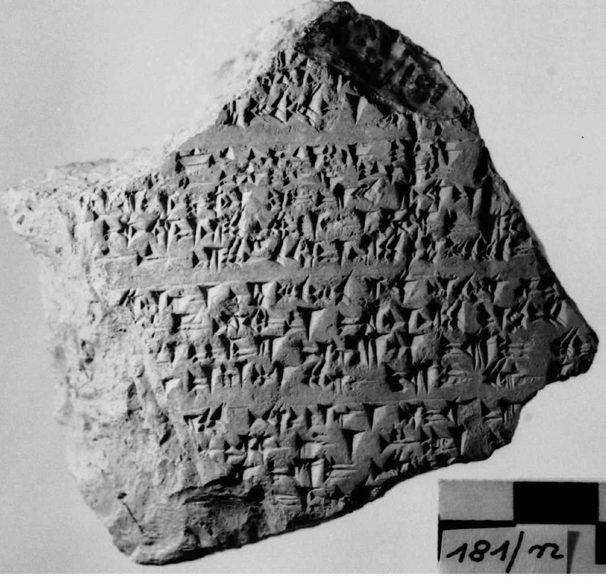

[figure not shown]

KBo 44.52

Filed under **CTH 470**, “ritual fragments”. Has 50 words

Orphans and Archetypes · Mainz, 18 November 2026

KBo 44.52: the text

1′

[x x x x x x x x x x x x x] x-⸢*a*⸣-*ḫi*-

2′

[x x x x x x x x x x x x] NINDA.SIG x x

3′

[x x x x x x x x x x x] ⸢EN⸣ SÍSKUR-*ma* ⸢*AN*⸣

4′

[x x x x x x x x x] {LÚ} SIMUG-*ia* *ku*-*e* x

5′

[x x x x x x x x] {⸢LÚ⸣} ḪAL *ša*-*ra*-*a* *da*-*a*-*i*

6′

[x x x x x] x{⸢ḪI⸣.A}-*ma*-*aš*-*ša*-*an* *ku*-*i*-*e*-*eš* *A*-*NA* {GIŠ} ⸢BANŠUR⸣

7′

[x x x x x x] x *da*-*aš*-⸢*ke*⸣-*ez*-*zi* *na*-*at*-⸢*kán*⸣ *ḫa*-*aš*-*ši*-*i* *zi*-[*ik*-*ke*-*ez*-*zi*]

8′

[x x x x x x]-⸢*in*⸣-*ni* *zi*-*ik*-⸢*ke*⸣-*ez*-*zi* EN SÍSKUR-⸢*ma*⸣

9′

[x x x x x x x] ⸢*na*⸣-*an*-*kán* EN SÍSKUR *A*-*NA* {D} *IŠTAR* *ši*-*pa*-[*an*-*ti*]

10′

[x x x x x x x x x] ⸢*šu*⸣-⸢*up*⸣-*pa* *ḫu*-*u*-*i*-*šu* *da*-*an*-*zi* {UZU} GABA

11′

[x x x x x x x {GIŠ}] ⸢BANŠUR⸣ AD.KID *da*-*ga*-*a*-*an* *da*-*a*-*i* *še*-⸢*ra*⸣-[*aš*-*ša*-*an*]

12′

[x x x x x x x x *A*]-⸢*NA*⸣ {GIŠ} BANŠUR *še*-*er* ⸢*da*⸣-*a*-*i* *še*-*er* ⸢*ar*⸣-[*ḫa*]

13′

[x x x x x x x x]-⸢*zi*⸣ *na*-*at*-*kán* *an*-*da* *ú*-

14′

[x x x x x x x x] *nu*-*uš*-*ši*-*kán* {LÚ} AZU x

15′

[x x x x x x x x {GIŠ}] ⸢BANŠUR⸣ *da*-*a*-*i* *na*-⸢*an*⸣-⸢*ša*⸣-[*an*]

16′

[x x x x x x x x x x x]-⸢*ma*⸣-*aš*-⸢*ša*⸣-[*an*]

Orphans and Archetypes · Mainz, 18 November 2026

How a philologist would place the fragment

Gods · who is invoked?

**IŠTAR**: the patron of the ritual libates to Ištar (9′)

People · who acts?

**EN SÍSKUR** the ritual patron **LÚ ḪAL** and **LÚ AZU** the diviner-priests **LÚ SIMUG** a smith (4′)

Realia · what is handled?

**BANŠUR** tables **NINDA.SIG** flat bread fresh meat, the breast (**GABA**) the hearth (*ḫašši*)

Writing habits · how is it written?

*da-a-i* “places”, *zi-ik-ke-ez-zi* “keeps putting”, *ši-pa-an-ti* “libates”, *na-at-kán*

Orphans and Archetypes · Mainz, 18 November 2026

A computational approach does the same via counting

Every manuscript

becomes a list of counts: each word, and each sign sequence inside a word.

Every tradition

is the average of its manuscripts: a fingerprint of what is written and how.

Every fragment

goes to the closest fingerprint, if it is clearly the closest.

Words common everywhere (*nu*, *A-NA*) count little Rare, shared words count a lot

Orphans and Archetypes · Mainz, 18 November 2026

The method in four lines

In mathematics

In words

KBo 44.52

Count

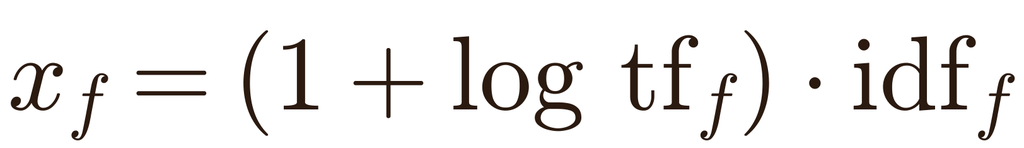

frequent here, rare in the corpus: it weighs more

*dai* 2.0 sign *an* 1.1

Compare

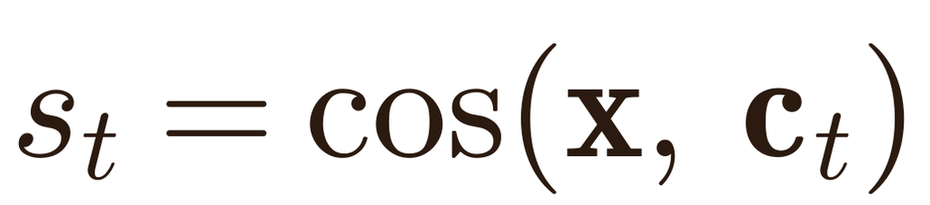

what the fragment shares with each archetype

0.42 vs 0.31

Decide

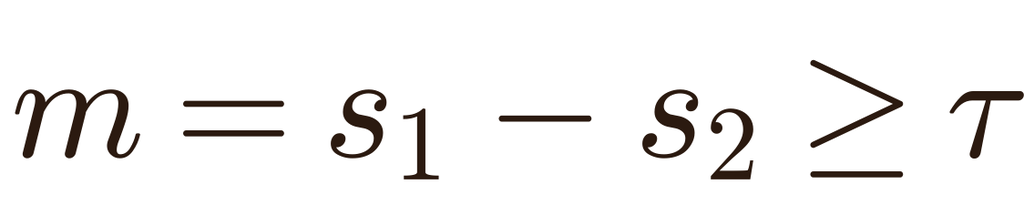

a clear lead, or else: undecided

0.11 ≥ 0.026

Explain

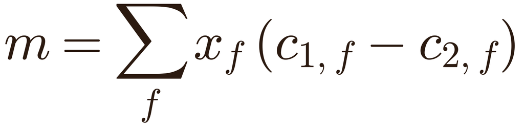

one share per word: the words to check

*dai*, AZU

Orphans and Archetypes · Mainz, 18 November 2026

Ten traditions in the scholarly literature

**Bold**: most cited study in the *Konkordanz* on a tradition’s manuscripts first cited → latest cited (based on simple counts)

North: Ḫattuša and its cult

Hattian cult layer

**Klinger 1996** · 443 MSS

Vieyra 1965 → Groddek 2026

Palaic festivals

**Steitler 2017** · 30 MSS

Carruba 1970 → Sasseville 2021

Ḫuwaššanna festivals

**Yoshida 1996** · 179 MSS

Goetze 1964 → Roth 2021

Luwian festivals

**Starke 1985** · 47 MSS

Jakob-Rost 1972 → Sasseville 2020

Orphans and Archetypes · Mainz, 18 November 2026

Ten traditions: rituals and Hurrian festivals

South and West: rituals

Hurrian festivals

Kizzuwatna rituals

**Miller 2004** · 211 MSS

Ehelolf 1932 → Torri 2022

Kizzuwatna–Lower Land

**Wegner–Salvini 1991** · 297 MSS

Kümmel 1967 → Reyhan 2025

Western (Arzawa) rituals

**Mouton 2010** · 32 MSS

Meriggi 1960 → Roth 2021

Syro-Mesopotamian

**Salvini–Wegner 1986** · 149 MSS

Rost 1953 → Roth 2021

Luwian rituals (Kuwattalla)

**Yakubovich–Mouton 2023** · 57 MSS

Otten 1969 · then Starke 1985

Mixed Hurrian-Syrian-Luwian

**Wegner 2002** · 190 MSS

Carruba 1966 → Groddek 2025

Orphans and Archetypes · Mainz, 18 November 2026

Orphans and Archetypes · Mainz, 18 November 2026

Test 1: hide a manuscript, then find it

Hattian cult layer

94%

Ḫuwaššanna festivals

92%

Kizzuwatna rituals

88%

Arzawa

88%

Luwian rituals

81%

Luwian festivals

79%

Kizzuwatna–Lower Land

77%

Palaic festivals

73%

Syro-Mesopotamian

68%

Mixed

67%

Only signs on the tablet count (with restorations: 84%).

Unanalysed words: same spelling elsewhere, or *eDiAna* (Luwian).

83%

of 1,634 manuscripts can be placed in a tradition when each is hidden in turn (guessing the largest tradition: 27%).

Orphans and Archetypes · Mainz, 18 November 2026

Test 2: hide a whole composition

Maštigga’s ritual

CTH 404 · 30 copies

→ **Kizzuwatna rituals** ✓

18 of 30 copies also singly

A Palaic festival

CTH 752 · 2 copies

→ **Hattian cult layer** ✗

Wrong, but the same festival world

AZU-priest rituals

CTH 701 · 108 copies

→ **Kizzuwatna rituals** ✗

The Syro-Mesopotamian tradition is known by these texts alone

Compositions found, by tradition: Hattian cult layer 25/25 · Ḫuwaššanna 5/5 · Luwian rituals 6/6 · Kizzuwatna rituals 24/26 · Mixed 3/4 · Arzawa 3/6 · Luwian festivals 2/4 · Kizzuwatna–Lower Land 3/8 · Syro-Mesopotamian 1/5 · Palaic 0/5

72 of 94

compositions still land in their tradition, with every copy hidden

How small can a fragment be?

Hide a known tablet, **KUB 29.4+** (CTH 481, Kizzuwatna), and break off pieces.

3 words

6 *še*-*kán* *na*-*at*

wrong: **unplaced**

10 words

6 *še*-*kán* *na*-*at* 2-*ŠU* *pa*-*az*-*za*-*na*-*a*-*an* …

right, unsure: **unplaced**

40 words

6 *še*-*kán* *na*-*at* … SÍG SA₅ SÍG ZA.GÌN … SÍG SIG₇.SIG₇ SÍG BABBAR …

**Kizzuwatna**: placed, right

All traditions: **45%** at 3 words · **59%** at 10 · **76%** at 40

Orphans and Archetypes · Mainz, 18 November 2026

Orphans and Archetypes · Mainz, 18 November 2026

Culture or scribes: what identifies a tradition?

What is written

SÍG ZA.GÌN

“blue wool”

→ Kizz.

*BE-EL*

“lord”

→ Ḫuwaššanna

GIŠ.{D}INANNA

“lyre”

→ Hattian

{LÚ}AZU

“diviner”

→ Syro-Mes.

67%

right from vocabulary alone

38%

from spelling habits (guessing the largest: 27%)

How it is spelled

*memai* “says” as *me-e-ma-i*

Kizz.–Lower Land

18%

Hattian cult layer

12%

Kizzuwatna rituals

1%

Syro-Mesopotamian

<1%

Each tradition’s scribal profile

[figure not shown]

**blue** more, **red** less than the average manuscript The differences are small

Orphans and Archetypes · Mainz, 18 November 2026

KBo 44.52: Placing a fragment is a tug of war

Syro-Mesopotamian (Hurrian)

AZU-priest rituals, CTH 701ff.

0.42

closeness

*dai*

AZU

ḪAL

BANŠUR

*natkan*

*tanzi*

*nankan*

← AZU rituals

Kizzuwatna →

Kizzuwatna rituals

the runner-up

0.31

closeness

**lead 0.11** Placed only if the lead is at least **0.026**: here it is four times that.

Orphans and Archetypes · Mainz, 18 November 2026

KBo 44.52: Which words decide

**Red** words pull toward the AZU rituals, **blue** words pull away.

5′

{⸢LÚ⸣} ḪAL

*ša*-*ra*-*a*

*da*-*a*-*i*

6′

*ku*-*i*-*e*-*eš*

*A*-*NA*

{GIŠ} ⸢BANŠUR⸣

7′

*da*-*aš*-⸢*ke*⸣-*ez*-*zi*

*na*-*at*-⸢*kán*⸣

*ḫa*-*aš*-*ši*-*i*

*zi*-[*ik*-*ke*-*ez*-*zi*]

8′

-⸢*in*⸣-*ni*

*zi*-*ik*-⸢*ke*⸣-*ez*-*zi*

EN

SÍSKUR-⸢*ma*⸣

9′

⸢*na*⸣-*an*-*kán*

EN

SÍSKUR

*A*-*NA*

{D} *IŠTAR*

*ši*-*pa*-[*an*-*ti*]

10′

⸢*šu*⸣-⸢*up*⸣-*pa*

*ḫu*-*u*-*i*-*šu*

*da*-*an*-*zi*

{UZU} GABA

11′

[{GIŠ}] ⸢BANŠUR⸣

AD.KID

*da*-*ga*-*a*-*an*

*da*-*a*-*i*

14′

*nu*-*uš*-*ši*-*kán*

{LÚ} AZU

Words create an ensemble: the diviners (**AZU**, **ḪAL**), the ritual patron (**EN SÍSKUR**), tables, and how things are put down (*da-a-i*, *na-at-kán*). Common words carry only 28% of the decision.

Orphans and Archetypes · Mainz, 18 November 2026

KBo 44.52 against ten archetypes

Syro-Mesopotamian

[figure not shown]

28

Mixed Hurrian

[figure not shown]

12

Kizzuwatna–Lower Land

[figure not shown]

11

Luwian rituals

[figure not shown]

10

Kizzuwatna rituals

[figure not shown]

9

Ḫuwaššanna festivals

[figure not shown]

7

Arzawa

[figure not shown]

5

Hattian cult layer

[figure not shown]

5

Palaic festivals

[figure not shown]

5

Luwian festivals

[figure not shown]

2

KBo 44.52 has it

has it, but common everywhere

Orphans and Archetypes · Mainz, 18 November 2026

Orphans and Archetypes · Mainz, 18 November 2026

KBo 44.52 closest mss: the AZU-priest rituals

6 of 10

closest manuscripts are CTH 701: the rituals of the AZU-priest (Salvini and Wegner)

manuscript

filed

tradition

closeness

KBo 59.165

CTH 701

Syro-Mesopotamian

0.34

KBo 60.215

CTH 701

Syro-Mesopotamian

0.33

ABoT 2.230

CTH 701

Syro-Mesopotamian

0.33

KUB 44.44

CTH 500

Kizzuwatna fragments

0.31

KBo 39.167

CTH 706

Mixed Hurrian

0.31

KBo 40.35+

CTH 701

Syro-Mesopotamian

0.30

KBo 13.167

CTH 500

Kizzuwatna fragments

0.29

KBo 40.314+

CTH 701

Syro-Mesopotamian

0.29

KBo 33.110+

CTH 701

Syro-Mesopotamian

0.28

KBo 38.284

CTH 500

Kizzuwatna fragments

0.28

KBo 44.52 finds a home: a paper trail ends?

**The tablet:** Bo 181/n, Büyükkale, at the inner edge of the Phrygian citadel wall. Brick-red baked clay. New Hittite.

**Roszkowska-Mutschler**, DBH 22 (2007) 46f.: transliteration only. CTH 470, New Hittite.

**van den Hout**, ZA 96 (2006) 281: notes that the sign SIMUG (line 4′) is a new variant of DÉ.

Neither name a composition

[figure not shown]

© Nippon Animation, 1976

The counting proposes

a home among the Syro-Mesopotamian AZU-priest rituals (CTH 701ff.), and its manuscripts.

Orphans and Archetypes · Mainz, 18 November 2026

KBo 57.54: A home built on restorations

KBo 57.54: the word that decided it

r. Kol. 3′

*nu*-*za*-*kán* {MUNUS}[ŠU.GI

r. Kol. 7′

⸢*ma*⸣-*a*-*an* {MUNU[S}ŠU.GI

the Old Woman: restored, both times

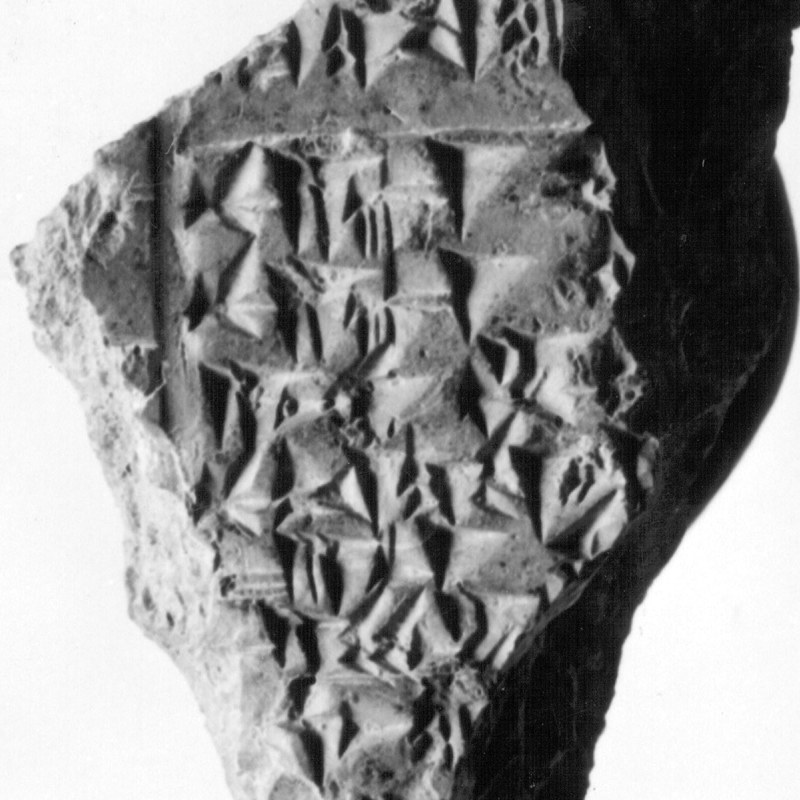

with the editor’s restorations

**Luwian rituals**

13 words, lead 0.059

only signs preserved on the tablet

**unplaced**

11 words, lead 0.017

Orphans and Archetypes · Mainz, 18 November 2026

A "new" group of fragments: EBo 133

Rediscovered in Boğazköy in 2025. Filed under **CTH 670**, “festival fragments”. 19 words. No *Konkordanz* entry.

A 2′

[{NINDA}*ta*-*kar*-*mu*]-*un* *pár*-[*ši*-*ia*]

A 3′

-⸢*pa*⸣-*an* 1-*ŠU*

A 4′

[{NINDA}*ta*-*kar*-*mu*]-⸢*un*⸣ *pár*-*ši*-*ia* x

A 5′

1-⸢*ŠU*⸣ *e*-*ku*-*zi* 1 NINDA *pár*-*ši*-[*ia*]

A 6′

x *ki*-*iš*-*an* x

A 7′

[{NINDA}*ta*]-⸢*kar*⸣-*mu*-*un* *pár*-[*ši*-*ia*]

A 8′

DINGIR {MEŠ} *ir*-*ḫa*-*a*-*ez*-*zi*

A 9′

x *pa*-*ra*-*a*

A 10′

x *e*-*ša*-x

A 11′

*ak*-*ku*-*uš*-⸢*ke*⸣-*ez*-*zi*

B 2′

*pár*-*ši*-*ia*

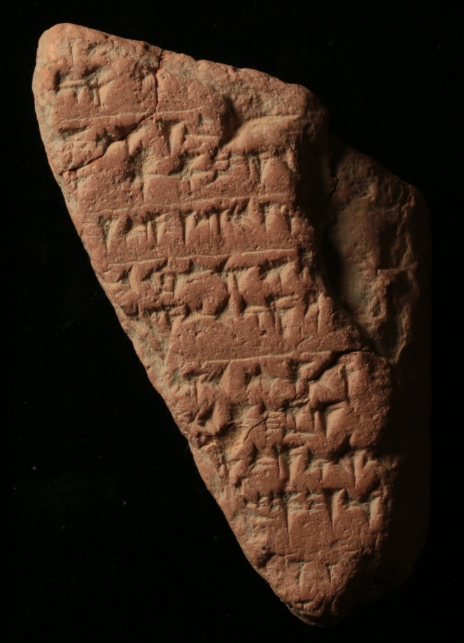

photo courtesy D. Schwemer

Orphans and Archetypes · Mainz, 18 November 2026

EBo 133: a tie between two festivals

Palaic festivals

CTH 750–754

0.25

closeness

1-*ŠU* · *pár-ši-ia* *ak-ku-uš-ke-ez-zi*

*takarmun*

Ḫuwaššanna festivals

CTH 690–694

0.25

closeness

**lead 0.007** far below 0.026: the counting cannot decide With the restored signs counted, Ḫuwaššanna led by 0.04

Orphans and Archetypes · Mainz, 18 November 2026

Follow the bread: where else is *takarmu-* broken?

54 of 62

reference manuscripts that have *takarmun* on the tablet are Ḫuwaššanna festivals.

Palaic festivals: 2.

**37** more festival fragments (CTH 670) have the same bread: candidates for the same home.

Orphans and Archetypes · Mainz, 18 November 2026

A join to look for: KBo 44.140

Same words, **same spellings**, shared phrases:

*takarmun*

*paršia*

1-*ŠU*

*ekuzi*

NINDA

*kišan*

DINGIR

*irḫaizi*

*para*

*akkuškezi*

**filled**: also in KBo 44.140, spelled the same

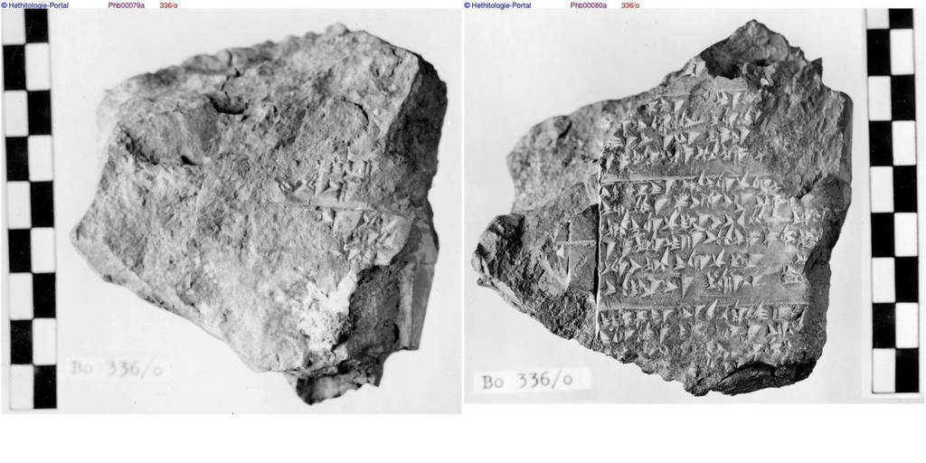

CTH 669 · NH script

KBo 44.140 Vs. III 8′–9′

… *e*-*ku*-⸢*zi*⸣ / 1 {NINDA}*ta*-*kar*-*mu*-*un* *pár*-*ši*-⸢*ia*⸣

EBo 133 A 4′–5′

[{NINDA}*ta*-*kar*-*mu*]-⸢*un*⸣ *pár*-*ši*-*ia* x / 1-⸢*ŠU*⸣ *e*-*ku*-*zi* 1 NINDA *pár*-*ši*-[*ia*]

“he drinks (once), he breaks one *takarmu*-bread”

Orphans and Archetypes · Mainz, 18 November 2026

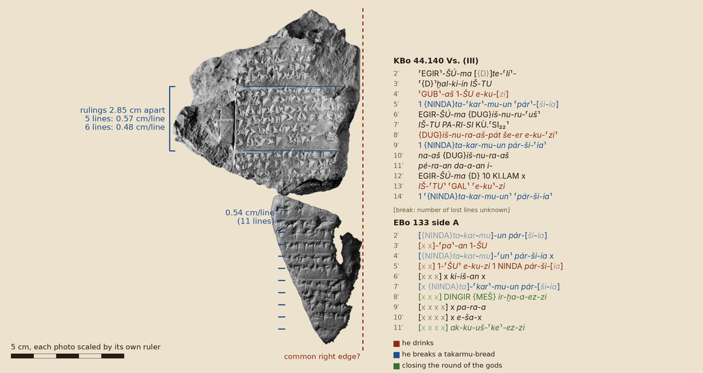

KBo 44.140+EBo 133??

Orphans and Archetypes · Mainz, 18 November 2026

How I suggest placing a fragment

1

Count only the visible words

EBo 133: a tie, lead 0.007.

2

Read the diagnostic word

*takarmu-* bread: 54 of 62 manuscripts are Ḫuwaššanna.

3

Read the closest manuscripts (in computational terms)

Ḫuwaššanna KBo 34.228, KBo 34.221 against Palaic DBH 46/2.139.

4

Check the tablet

KBo 44.140: same formula, same spellings.

Proposal for EBo 133: Ḫuwaššanna festival, possibly part of the tablet KBo 44.140 (to be checked physically)

Orphans and Archetypes · Mainz, 18 November 2026

How does this help cuneiform analysis?

1. A (possible) home

457 of 2,023 orphans placed at 80% precision, each with its diagnostic words

2. Archetype and witness

Traditions are known by what is written (whom and what a text names), hardly by spelling

3. Genre before origin

A placement means “nearest of these”: only as good as the alternatives

4. Restorations measured

KBo 57.54: its diagnostic word was restored

5. Parallels and joins as leads

EBo 133 and KBo 44.140

[figure not shown]

Try it online

Adoptio

A quantitative tool for placing Hittite fragments

shaigordin.github.io/text-orphans

Orphans and Archetypes · Mainz, 18 November 2026

Bibliography

Data and tools

Müller, G., D. Prechel, E. Rieken, D. Schwemer 2026. *Thesaurus Linguarum Hethaeorum digitalis (TLHdig)*, Beta Version 0.3. Zenodo, doi:10.5281/zenodo.20328284.

Košak, S. 2026. *Konkordanz der hethitischen Keilschrifttafeln*. hethiter.net/: hetkonk.

Košak, S., G.G.W. Müller, S. Görke, Ch.W. Steitler 2026. *Catalog der Texte der Hethiter (CTH)*. hethiter.net/: CTH.

Laroche, E. 1971. *Catalogue des textes hittites*. Paris: Klincksieck.

Rieken, E., D. Schwemer 2026. *Corpus der hethitischen Festrituale (HFR)*. AdW Mainz, hethiter.net/: HFR.

*eDiAna: Digital Philological-Etymological Dictionary of the Minor Ancient Anatolian Corpus Languages*. LMU München, ediana.gwi.uni-muenchen.de.

Mainzer Fotoarchiv, hethiter.net/: fotarch (photo numbers in the slide notes). Font UllikummiA © S. Vanséveren.

Builds on

Gordin, S., E. Yavasan, A. Romach 2025. Matters of Genre, Style and Orthography: Hittite Scribal Habits through the Stylometric Lens. In S. Görke et al. (eds), *The Tablets and Their Scribes*. StBoT 73. Wiesbaden: 107–123.

Yavasan, E., S. Gordin 2025. From Clay to Code: Transforming Hittite Texts for Machine Learning. *Proceedings of ALP 2025*. ACL: 77–86.

This case

Roszkowska-Mutschler, H. 2007. *Hethitische Texte in Transkription KBo 44*. DBH 22. Wiesbaden: 46f. (KBo 44.52), 126–128 (KBo 44.140).

van den Hout, Th. 2006. Review of H. Otten and Ch. Rüster, *Textfunde von Büyükkale* (KBo 44). ZA 96: 280–283 (281 on KBo 44.52).

HPM news, 22.11.2025: EBo 73–1446 added to TLHdig (hethport.net/HPM/new.php).

Photos of EBo 133: courtesy of D. Schwemer (2026).

Groddek, D. 2011. DBH 36: 30f. (KBo 57.54; as cited in the *Konkordanz*).

Orphans and Archetypes · Mainz, 18 November 2026

Bibliography: the ten traditions

Most-cited studies

Klinger, J. 1996. *Untersuchungen zur Rekonstruktion der hattischen Kultschicht*. StBoT 37. Wiesbaden.

Miller, J.L. 2004. *Studies in the Origins, Development and Interpretation of the Kizzuwatna Rituals*. StBoT 46. Wiesbaden.

Mouton, A. 2010. JCS 62.

Salvini, M., I. Wegner 1986. *Die Rituale des AZU-Priesters*. ChS I/2. Roma.

Starke, F. 1985. StBoT 30.

Steitler, Ch.W. 2017. StBoT 62.

Wegner, I. 2002. ChS I/3-2.

Wegner, I., M. Salvini 1991. *Die hethitisch-hurritischen Ritualtafeln des (ḫ)išuwa-Festes*. ChS I/4. Roma.

Yakubovich, I., A. Mouton 2023. StBoT 72,1.

Yoshida, D. 1996. THeth 22.

First and latest studies per tradition

Carruba StBoT 2, 1966 · Carruba StBoT 10, 1970 · Ehelolf MDOG 70, 1932 · Goetze JCS 18, 1964 · Groddek FsTaracha, 2026 · Groddek Fs van den Hout, 2025 · Jakob-Rost THeth 2, 1972 · Kümmel StBoT 3, 1967 · Meriggi RHA XVIII/66–67, 1960 · Otten–Souček StBoT 8, 1969 · Reyhan ArAn 19/2, 2025 · Rost MIO 1, 1953 · Roth BSIEL 23, 2021 · Sasseville BSIEL 21, 2020 · Sasseville FsKosyan, 2023 · Sasseville–Yakubovich KZ 131, 2021 · Torri StBoT 67, 2022 · Vieyra RA 59, 1965

Orphans and Archetypes · Mainz, 18 November 2026

Bibliography: textual criticism and stylometry

Burrows, J. 2002. ‘Delta’: A Measure of Stylistic Difference and a Guide to Likely Authorship. *Literary and Linguistic Computing* 17(3): 267–287.

Eder, M. 2015. Does Size Matter? Authorship Attribution, Small Samples, Big Problem. *Digital Scholarship in the Humanities* 30(2): 167–182.

Koppel, M., J. Schler, S. Argamon 2011. Authorship Attribution in the Wild. *Language Resources and Evaluation* 45(1): 83–94.

Maas, P. 1958. *Textual Criticism*. Transl. B. Flower. Oxford: Clarendon Press.

Roos, T., T. Heikkilä 2009. Evaluating Methods for Computer-Assisted Stemmatology Using Artificial Benchmark Data Sets. *Literary and Linguistic Computing* 24(4): 417–433.

Simonjetz, F., J. Laasonen, Y. Cobanoglu, A. Fraser, E. Jiménez 2024. Reconstruction of Cuneiform Literary Texts as Text Matching. *Proceedings of LREC-COLING 2024*: 13712–13721.

Trovato, P. 2014. *Everything You Always Wanted to Know about Lachmann’s Method*. Padova: libreriauniversitaria.it.

Orphans and Archetypes · Mainz, 18 November 2026

Count only what is on the clay

**A sign counts** if it is on the tablet, even damaged.

**A word counts** if half its signs survive, or if it is readable elsewhere on the same tablet.

**Restorations from a duplicate never count.** They show the comparative text, not what is on the tablet.

**A word without analysis** takes that of the same spelling elsewhere, or its *eDiAna* lemma (Luwian).

[grey] = restored by the editor, ⸢ ⸣ = damaged

Orphans and Archetypes · Mainz, 18 November 2026

KBo 44.52: which words count?

8′

*zi*-*ik*-⸢*ke*⸣-*ez*-*zi*

on the tablet: counts

7′

*zi*-[*ik*-*ke*-*ez*-*zi*]

1 of 5 signs, but 8′ has it whole: counts

9′

*ši*-*pa*-[*an*-*ti*]

half the word: counts

11′

*še*-⸢*ra*⸣-[*aš*-*ša*-*an*]

2 of 5 signs, nowhere else: left out

[grey] = restored by the editor, ⸢ ⸣ = damaged

Orphans and Archetypes · Mainz, 18 November 2026